# CLT. Simulations

## Normal probability plot

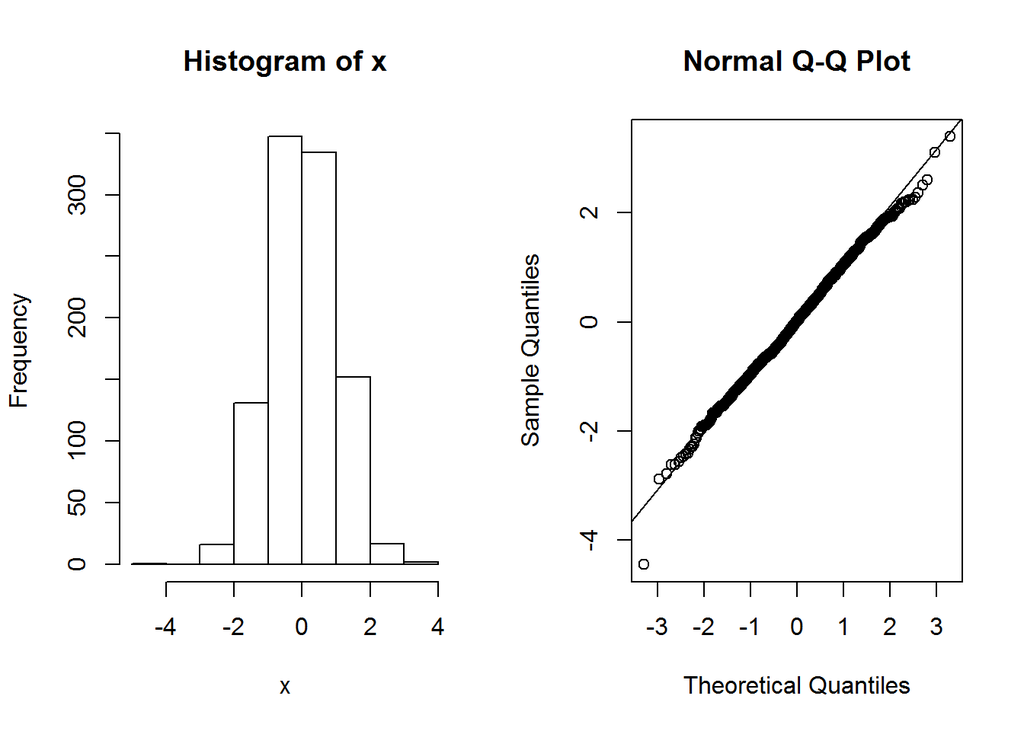

```r
x=rnorm(1000)#generate 1000 random numbers from normal distribution with mean 0 and std   1
par(mfrow=c(1,2))#create 2 plots on one picture
hist(x)
qqnorm(x)# normal probability plot
qqline(x)#straight line on normal probability plot
```

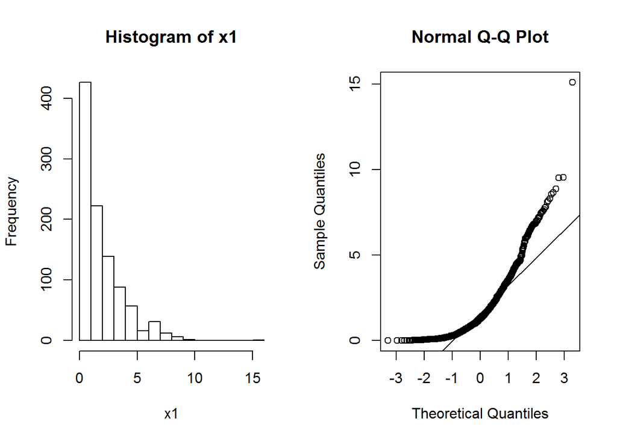

```r
x1=rexp(1000, 0.5)#generate 1000 random numbers from exponential distribution with lambda=0.5
par(mfrow=c(1,2))
hist(x1)
qqnorm(x1)
qqline(x1)
```

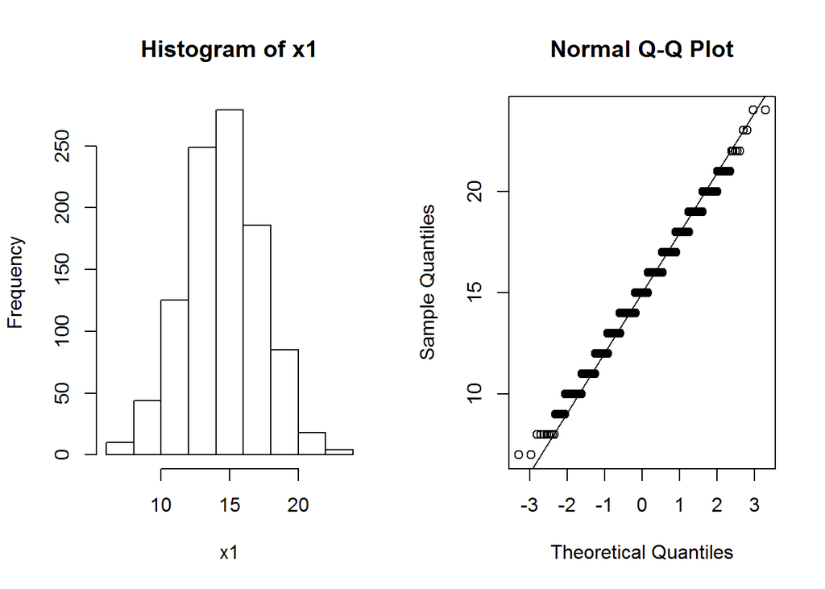

```r
x1=rbinom(1000,30, 0.5) #generate 1000 random numbers from binomial  distribution with n=30, p=0.5
par(mfrow=c(1,2))
hist(x1)
qqnorm(x1)
qqline(x1)
```

## Example for central limit theorem

```r
#m=numeric(10000);
#p=0.75; for(j in (1:50)){ k=j*j
 #                          for(i #in(1:10000)){m[i]=(mean(rbinom(k,1,p))-p)/sqrt(p*(1-p)/k)}
 #                          hist(m,breaks=41,xlim=c(-4,4),main=sprintf("%d",k))
#}
```

```r
n1=15
n2=30
n3=100
n4=1000
```

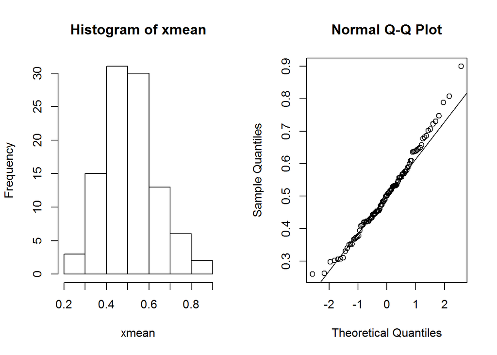

```r
n=n1
Y=rexp(100*n, 2) # simulate random numbers
X=matrix(Y, n,100) # reshape them into the matrix
xmean=apply(X,2,mean) #calculate mean of each column
par(mfrow=c(1,2))
hist(xmean)
qqnorm(xmean)
qqline(xmean)
```

Estimate for mean of means and variance of means

```r
mean(xmean)
```

```
## [1] 0.5070837
```

```r
var(xmean)
```

```
## [1] 0.01593452
```

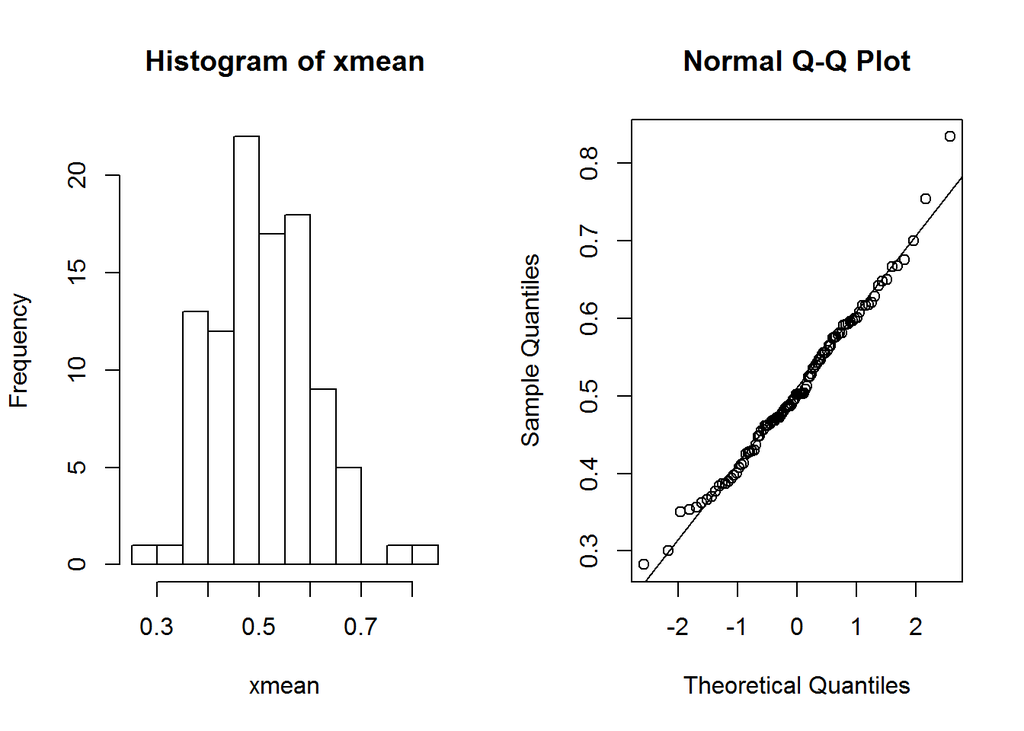

```r
n=n2
Y=rexp(100*n, 2) # simulate random numbers
X=matrix(Y, n,100) # reshape them into the matrix
xmean=apply(X,2,mean) #calculate mean of each column
par(mfrow=c(1,2))
hist(xmean)
qqnorm(xmean)
qqline(xmean)
```

Estimate for mean of means and variance of means

```r
mean(xmean)
```

```
## [1] 0.5080553
```

```r
var(xmean)
```

```
## [1] 0.009696297
```

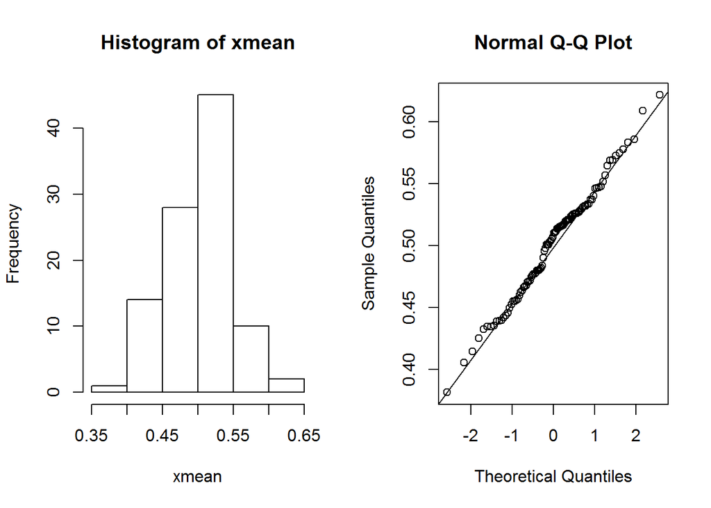

```r
n=n3
Y=rexp(100*n, 2) # simulate random numbers
X=matrix(Y, n,100) # reshape them into the matrix
xmean=apply(X,2,mean) #calculate mean of each column
par(mfrow=c(1,2))
hist(xmean)
qqnorm(xmean)
qqline(xmean)
```

Estimate for mean of means and variance of means

```r
mean(xmean)
```

```
## [1] 0.5013409
```

```r
var(xmean)
```

```
## [1] 0.002114281
```

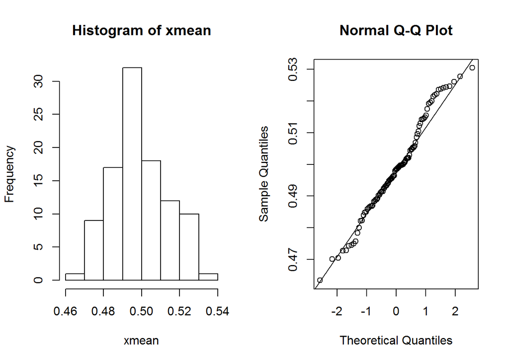

```r
n=n4
Y=rexp(100*n, 2) # simulate random numbers
X=matrix(Y, n,100) # reshape them into the matrix
xmean=apply(X,2,mean) #calculate mean of each column
par(mfrow=c(1,2))
hist(xmean)
qqnorm(xmean)
qqline(xmean)
```

Estimate for mean of means and variance of means

```r
mean(xmean)
```

```
## [1] 0.4986837
```

```r
var(xmean)
```

```
## [1] 0.0002212962
```

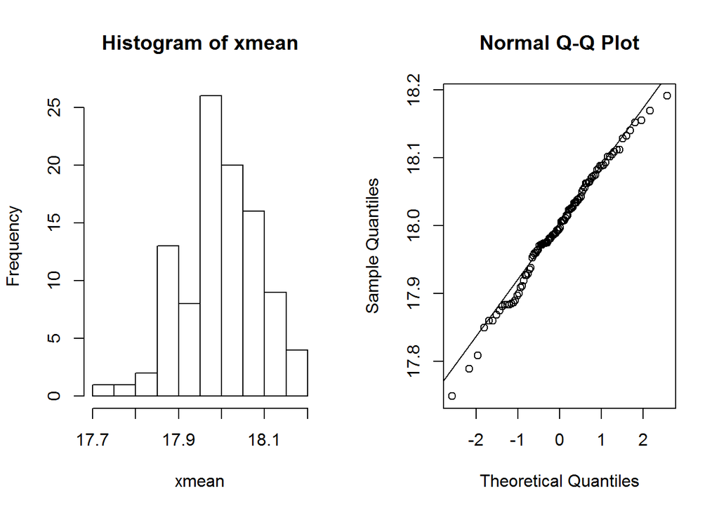

```r
Y=rbinom(100*n,  30, 0.6)
X=matrix(Y,n,100)#reshape data to the matrix n x 100
xmean=apply(X,2,mean)#calculate mean by column
par(mfrow=c(1,2))
hist(xmean)
qqnorm(xmean)
qqline(xmean)
```

```r
mean(xmean) #check the mean of the means, which value do you expect?
```

```
## [1] 17.99831
```

```r
var(xmean) #check the variance of the means, which value do you expect?
```

```
## [1] 0.007627772
```

## Simulations, Examples of problems

Example with resistors An electrical engineer will connect two resistors labelad 100 Om and 25 om in parrallel. The actual reistance may differ from the labelad values. Denote he actual resistance of the resisters that are choosen X and Y. The total esistance is $R=XY\(X+Y)$. Assume $X \sim Normal(\mu=100, \sigma=10)$ distr, $Y \sim Normal(\mu=25, \sigma=2.5)$ and the resistors are choosen independantly. Find $P(19<R<21)$

```r
x=rnorm(1000, mean=100, sd=10)
y=rnorm(1000, mean=25, sd=2.5)
R=x*y/(x+y)
RP=R[R>19 & R<21]
(Prob=length(RP)/length(x))
```

```
## [1] 0.443
```

Example 2. An engineer has to choose between two types of cooling fans to install in a computer A~Exponential distributon with mean life 50 month, B follows exp with mean 30 month. Since type A fans are more expensive, the engineer decides that she will choose type A fans if P(A>2B)>0.5. Estimate this probability.

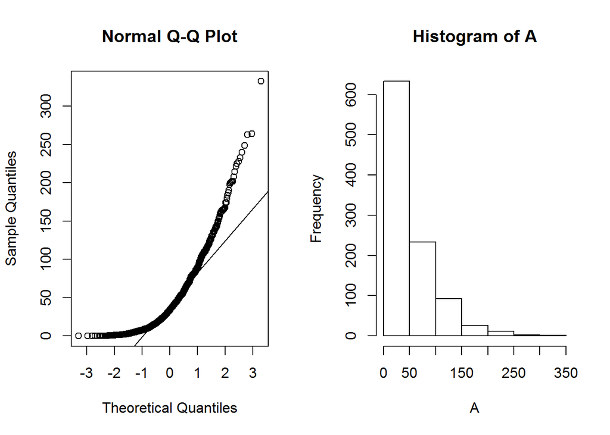

```r
A=rexp(1000, 1/50)
B=rexp(1000, 1/30)
par(mfrow=c(1,2))
qqnorm(A)
qqline(A)
hist(A)
```

```r
C=A-2*B
(Prob=length(C[C>0])/length(A))
```

```
## [1] 0.455
```

Example for reability analysis,

```r
A=rexp(1000,1) #generate random numbers from exp(1)
B=rexp(1000, 0.5) #generate random numbers from exp(0.5).
L=pmax(A,B)#calculate max for every pair
mean(L)
```

```
## [1] 2.259498
```

```r
PP=length(L[L<1])/length(A)#
```

```r
Lsorted=sort(L)
Lsorted[100]
```

```
## [1] 0.5286116
```

```r
quantile(L,0.1) #calculate sample 10 precentile
```

```
##       10%
## 0.5391003
```